# ICC for eMCCD pilot

# Assumptions

- Facilities and also service level (district, regional, tertiary) may produce clustered probabilities of grabage coding.
- There is also a relationship of paired observations - paper vs electronic certificate on the same death are maybe be very similar ie. If not ill-defined on paper, perhaps unlikely to be ill-defined on electronic (depends on incentive and UX)

## Data Preparation

We focus on natural hospital deaths during 2019–2020, mirroring the training window used for the eMCCD pilot analyses.

# ICC from hierarchy using district as proxy for facility

Table 1: Odds associated with having a garbage code from mixed effects logistic regression

| Characteristic | OR | 95% CI | p-value |
| --- | --- | --- | --- |
| agegroup |  |  |  |
| 5-39 | — | — |  |
| 40-59 | 1.13 | 1.10, 1.16 | <0.001 |
| 60-69 | 1.41 | 1.38, 1.45 | <0.001 |
| epi_year | 0.96 | 0.96, 0.96 | <0.001 |
| Sex of deceased | 1.00 | 0.98, 1.02 | 0.7 |
| No. Obs. | 244,458 |  |  |
| Sigma | 1.00 |  |  |
| Log-likelihood | -115,756 |  |  |
| AIC | 231,525 |  |  |
| BIC | 231,598 |  |  |
| Deviance | 231,288 |  |  |
| Residual df | 244,451 |  |  |

Abbreviations: CI = Confidence Interval, OR = Odds Ratio

0.0212995, 0.0211867, 0.0211867 is the estimated overall ICC from the hierarchical model.

A design effect of 3.75, 3.73, 3.73 is implied for this ICC.

I do not think that it is granular enough to show the different facility type and rural/urban clustering. I think we have shown that place of death has high variablity in garbage coding, but we are already limiting ourelves to hospital deaths only.

A larger concern is the paired nature of the data whereby we are expecting an improvement in data without new data, but rather just with validation checks, in addition, we are also assuming that the electronic data will *only* improve the data.

# We have two endpoints to consider here:

- misclassification probability of garbage coding on electronic MCCD
- misclassification probability of garbage coding on paper MCCD

There are 4 outcomes: - both paper and electronic are well defined - paper is well defined, electronic is garbage - paper is garbage, electronic is well defined - both paper and electronic are garbage

We can define the following probabilities:

- p1: prob of garbage coding on paper MCCD
- p2: prob of garbage coding on electronic MCCD
- p01: prob of paper well defined, electronic garbage
- p10: prob of paper garbage, electronic well defined
- rho: correlation between the two endpoints within cluster

We can then use these to estimate the joint misclassification probabilities and then use these to estimate power/sample size curves for various scenarios.

| Characteristic | 5-39 2019 N = 2,9081 | 5-39 2020 N = 3,1051 | 5-39 p-value2 | 40-59 2019 N = 6,2231 | 40-59 2020 N = 7,4711 | 40-59 p-value2 | 60-69 2019 N = 4,2501 | 60-69 2020 N = 5,5371 | 60-69 p-value2 |
| --- | --- | --- | --- | --- | --- | --- | --- | --- | --- |
| hiv_pos | 141 (4.8%) | 127 (4.1%) | 0.2 | 150 (2.4%) | 142 (1.9%) | 0.040 | 33 (0.8%) | 27 (0.5%) | 0.070 |
| garbage_bin | 361 (12%) | 413 (13%) | 0.3 | 911 (15%) | 953 (13%) | 0.001 | 716 (17%) | 781 (14%) | <0.001 |

1n (%)  
2Pearson's Chi-squared test

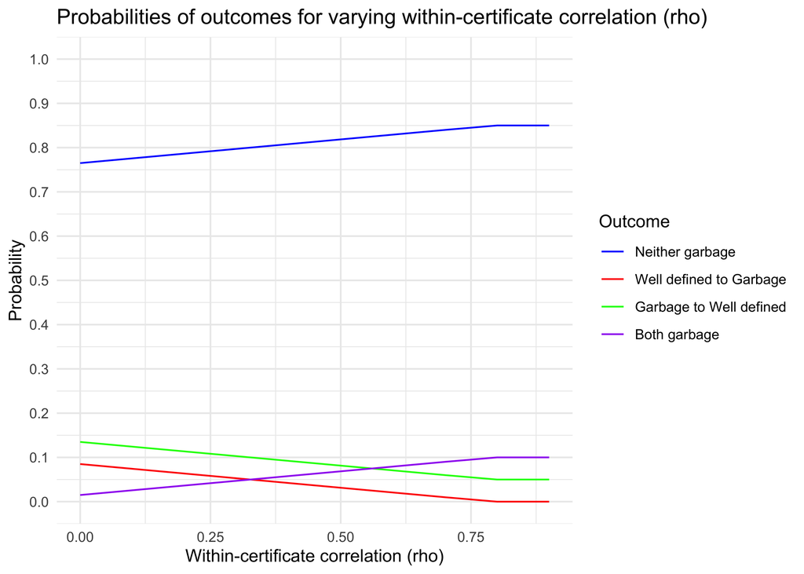

Figure 1: Joint misclassification probabilities

[figure not shown]